# Wildfire_spread_prediction_v1

```
Mean Absolute Error: 1.74 km/h
```

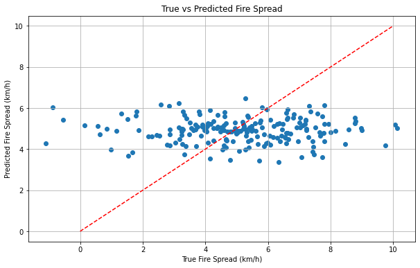

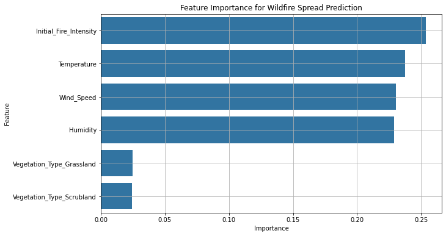

```python
# Import necessary libraries
import pandas as pd
import numpy as np
from sklearn.model_selection import train_test_split
from sklearn.ensemble import RandomForestRegressor
from sklearn.metrics import mean_absolute_error
import matplotlib.pyplot as plt
import seaborn as sns

# Create a synthetic dataset
np.random.seed(42)
data = {
    'Temperature': np.random.normal(30, 5, 1000),  # Temperature in degrees Celsius
    'Humidity': np.random.normal(40, 10, 1000),  # Relative humidity percentage
    'Wind_Speed': np.random.normal(15, 5, 1000),  # Wind speed in km/h
    'Vegetation_Type': np.random.choice(['Forest', 'Grassland', 'Scrubland'], 1000),
    'Initial_Fire_Intensity': np.random.normal(0.5, 0.1, 1000),  # Initial fire intensity
    'Fire_Spread': np.random.normal(5, 2, 1000)  # Fire spread (in km/h)
}

# Convert the dataset to a DataFrame
df = pd.DataFrame(data)

# Convert categorical variables to numerical (one-hot encoding for Vegetation_Type)
df = pd.get_dummies(df, columns=['Vegetation_Type'], drop_first=True)

# Split the data into features (X) and target (y)
X = df.drop('Fire_Spread', axis=1)
y = df['Fire_Spread']

# Split into training and testing datasets
X_train, X_test, y_train, y_test = train_test_split(X, y, test_size=0.2, random_state=42)

# Train a RandomForestRegressor model
model = RandomForestRegressor(n_estimators=100, random_state=42)
model.fit(X_train, y_train)

# Predict fire spread on the test set
y_pred = model.predict(X_test)

# Evaluate the model
mae = mean_absolute_error(y_test, y_pred)
print(f"Mean Absolute Error: {mae:.2f} km/h")

# Plot the true vs predicted fire spread
plt.figure(figsize=(10, 6))
plt.scatter(y_test, y_pred)
plt.plot([0, 10], [0, 10], color='red', linestyle='--')
plt.xlabel('True Fire Spread (km/h)')
plt.ylabel('Predicted Fire Spread (km/h)')
plt.title('True vs Predicted Fire Spread')
plt.grid(True)
plt.show()

# Plot Feature Importance
feature_importance = model.feature_importances_

# Create a DataFrame to make the plot easier to handle
importance_df = pd.DataFrame({
    'Feature': X.columns,
    'Importance': feature_importance
})

# Sort the feature importances
importance_df = importance_df.sort_values(by='Importance', ascending=False)

# Plotting the feature importance
plt.figure(figsize=(10, 6))
sns.barplot(x='Importance', y='Feature', data=importance_df)
plt.title('Feature Importance for Wildfire Spread Prediction')
plt.xlabel('Importance')
plt.ylabel('Feature')
plt.grid(True)
plt.show()
```

```
Mean Absolute Error for Fire Spread Speed: 1.57 km/h
Mean Absolute Error for Fire Direction: 91.55 degrees
Mean Absolute Error for Fire Area: 25.98 km²
```

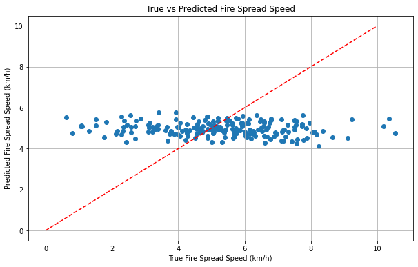

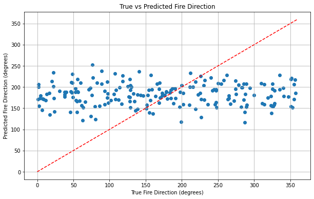

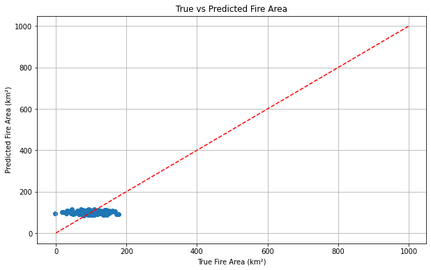

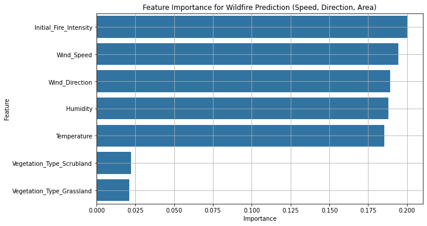

```python
# Import necessary libraries
import pandas as pd
import numpy as np
from sklearn.model_selection import train_test_split
from sklearn.ensemble import RandomForestRegressor
from sklearn.metrics import mean_absolute_error
import matplotlib.pyplot as plt
import seaborn as sns

# Create a synthetic dataset with fire area, wind direction, and speed
np.random.seed(42)
data = {
    'Temperature': np.random.normal(30, 5, 1000),  # Temperature in degrees Celsius
    'Humidity': np.random.normal(40, 10, 1000),  # Relative humidity percentage
    'Wind_Speed': np.random.normal(15, 5, 1000),  # Wind speed in km/h
    'Wind_Direction': np.random.uniform(0, 360, 1000),  # Wind direction in degrees (0-360)
    'Vegetation_Type': np.random.choice(['Forest', 'Grassland', 'Scrubland'], 1000),
    'Initial_Fire_Intensity': np.random.normal(0.5, 0.1, 1000),  # Initial fire intensity
    'Fire_Spread': np.random.normal(5, 2, 1000),  # Fire spread speed (in km/h)
    'Fire_Direction': np.random.uniform(0, 360, 1000),  # Fire spread direction (in degrees)
    'Fire_Area': np.random.normal(100, 30, 1000)  # Fire area in km² (area affected)
}

# Convert the dataset to a DataFrame
df = pd.DataFrame(data)

# Convert categorical variables to numerical (one-hot encoding for Vegetation_Type)
df = pd.get_dummies(df, columns=['Vegetation_Type'], drop_first=True)

# Split the data into features (X) and targets (y)
X = df.drop(['Fire_Spread', 'Fire_Direction', 'Fire_Area'], axis=1)  # Features
y = df[['Fire_Spread', 'Fire_Direction', 'Fire_Area']]  # Targets (speed, direction, area)

# Split into training and testing datasets
X_train, X_test, y_train, y_test = train_test_split(X, y, test_size=0.2, random_state=42)

# Train a RandomForestRegressor model for fire speed, direction, and area prediction
model = RandomForestRegressor(n_estimators=100, random_state=42)

# Fit the model to predict fire speed, direction, and area
model.fit(X_train, y_train)

# Predict fire spread speed, direction, and area on the test set
y_pred = model.predict(X_test)

# Evaluate the model
mae_speed = mean_absolute_error(y_test['Fire_Spread'], y_pred[:, 0])
mae_direction = mean_absolute_error(y_test['Fire_Direction'], y_pred[:, 1])
mae_area = mean_absolute_error(y_test['Fire_Area'], y_pred[:, 2])

print(f"Mean Absolute Error for Fire Spread Speed: {mae_speed:.2f} km/h")
print(f"Mean Absolute Error for Fire Direction: {mae_direction:.2f} degrees")
print(f"Mean Absolute Error for Fire Area: {mae_area:.2f} km²")

# Plot the true vs predicted fire spread speed
plt.figure(figsize=(10, 6))
plt.scatter(y_test['Fire_Spread'], y_pred[:, 0])
plt.plot([0, 10], [0, 10], color='red', linestyle='--')
plt.xlabel('True Fire Spread Speed (km/h)')
plt.ylabel('Predicted Fire Spread Speed (km/h)')
plt.title('True vs Predicted Fire Spread Speed')
plt.grid(True)
plt.show()

# Plot the true vs predicted fire direction
plt.figure(figsize=(10, 6))
plt.scatter(y_test['Fire_Direction'], y_pred[:, 1])
plt.plot([0, 360], [0, 360], color='red', linestyle='--')
plt.xlabel('True Fire Direction (degrees)')
plt.ylabel('Predicted Fire Direction (degrees)')
plt.title('True vs Predicted Fire Direction')
plt.grid(True)
plt.show()

# Plot the true vs predicted fire area
plt.figure(figsize=(10, 6))
plt.scatter(y_test['Fire_Area'], y_pred[:, 2])
plt.plot([0, 1000], [0, 1000], color='red', linestyle='--')
plt.xlabel('True Fire Area (km²)')
plt.ylabel('Predicted Fire Area (km²)')
plt.title('True vs Predicted Fire Area')
plt.grid(True)
plt.show()

# Plot Feature Importance
feature_importance = model.feature_importances_

# Create a DataFrame to make the plot easier to handle
importance_df = pd.DataFrame({
    'Feature': X.columns,
    'Importance': feature_importance
})

# Sort the feature importances
importance_df = importance_df.sort_values(by='Importance', ascending=False)

# Plotting the feature importance
plt.figure(figsize=(10, 6))
sns.barplot(x='Importance', y='Feature', data=importance_df)
plt.title('Feature Importance for Wildfire Prediction (Speed, Direction, Area)')
plt.xlabel('Importance')
plt.ylabel('Feature')
plt.grid(True)
plt.show()
```

```
Predicted Fire Spread Speed: 5.49 km/h
Predicted Fire Direction: 134.85 degrees
Predicted Fire Area: 102.21 km²
```

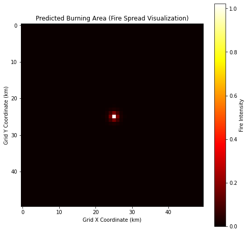

```python
import numpy as np
import matplotlib.pyplot as plt
from sklearn.ensemble import RandomForestRegressor
from sklearn.model_selection import train_test_split

# Create a synthetic dataset for the model
np.random.seed(42)
data = {
    'Temperature': np.random.normal(30, 5, 1000),  # Temperature in degrees Celsius
    'Humidity': np.random.normal(40, 10, 1000),  # Relative humidity percentage
    'Wind_Speed': np.random.normal(15, 5, 1000),  # Wind speed in km/h
    'Wind_Direction': np.random.uniform(0, 360, 1000),  # Wind direction in degrees (0-360)
    'Vegetation_Type': np.random.choice(['Forest', 'Grassland', 'Scrubland'], 1000),
    'Initial_Fire_Intensity': np.random.normal(0.5, 0.1, 1000),  # Initial fire intensity
    'Fire_Spread': np.random.normal(5, 2, 1000),  # Fire spread speed (in km/h)
    'Fire_Direction': np.random.uniform(0, 360, 1000),  # Fire spread direction (in degrees)
    'Fire_Area': np.random.normal(100, 30, 1000)  # Fire area in km² (area affected)
}

# Convert the dataset to a DataFrame
import pandas as pd
df = pd.DataFrame(data)

# Convert categorical variables to numerical (one-hot encoding for Vegetation_Type)
df = pd.get_dummies(df, columns=['Vegetation_Type'], drop_first=True)

# Split the data into features (X) and targets (y)
X = df.drop(['Fire_Spread', 'Fire_Direction', 'Fire_Area'], axis=1)  # Features
y = df[['Fire_Spread', 'Fire_Direction', 'Fire_Area']]  # Targets (speed, direction, area)

# Split into training and testing datasets
X_train, X_test, y_train, y_test = train_test_split(X, y, test_size=0.2, random_state=42)

# Train a RandomForestRegressor model for fire speed, direction, and area prediction
model = RandomForestRegressor(n_estimators=100, random_state=42)

# Fit the model to predict fire speed, direction, and area
model.fit(X_train, y_train)

# Predict fire spread speed, direction, and area on the test set
y_pred = model.predict(X_test)

# Assume we pick a single test sample for visualization
sample = X_test.iloc[0]
predicted_speed = y_pred[0][0]  # Fire spread speed in km/h
predicted_direction = y_pred[0][1]  # Fire spread direction in degrees
predicted_area = y_pred[0][2]  # Fire area in km²

print(f"Predicted Fire Spread Speed: {predicted_speed:.2f} km/h")
print(f"Predicted Fire Direction: {predicted_direction:.2f} degrees")
print(f"Predicted Fire Area: {predicted_area:.2f} km²")

# Now let's create a grid to visualize the predicted burning area
# Assuming a 100x100 grid (for example, a 100 km x 100 km area)
grid_size = 50
burning_area_grid = np.zeros((grid_size, grid_size))

# Let's simulate fire spread based on the predicted speed and direction
# We assume that the fire starts in the center of the grid
center_x, center_y = grid_size // 2, grid_size // 2

# We will simulate the fire's spread in a circular pattern
# The radius of the fire's spread is proportional to the predicted fire speed and area
# Higher speed means a larger area is affected in a given time frame

# Convert direction to radians for calculation
direction_radians = np.deg2rad(predicted_direction)

# Use a simple formula to spread the fire outwards
for x in range(grid_size):
    for y in range(grid_size):
        # Calculate the distance from the center (fire origin)
        distance = np.sqrt((x - center_x)**2 + (y - center_y)**2)

        # The intensity of the fire decreases with distance, but is affected by speed and area
        intensity = np.exp(-distance / (predicted_speed * 0.1)) * (predicted_area / 100)

        # Set the grid cell to the intensity value (scaled by the fire's spread)
        burning_area_grid[x, y] = intensity

# Visualize the predicted burning area
plt.figure(figsize=(8, 8))
plt.imshow(burning_area_grid, cmap='hot', interpolation='nearest')
plt.colorbar(label='Fire Intensity')
plt.title('Predicted Burning Area (Fire Spread Visualization)')
plt.xlabel('Grid X Coordinate (km)')
plt.ylabel('Grid Y Coordinate (km)')
plt.show()
```

Fire Spread Model:

We used a RandomForestRegressor to predict the fire speed, direction, and area based on a synthetic dataset. The predictions are made for a random test sample. Grid Simulation:

For each cell in the grid, we compute the distance from the center of the grid (fire origin). The intensity at each cell is calculated using an exponential decay function, where the intensity decreases with distance from the origin. The predicted fire area is used to scale the intensity, simulating how much area is affected. Visualization:

The imshow function is used to visualize the fire's spread on a grid. The grid's intensity values are shown using a 'hot' colormap to represent the burning area. Visualization: The output is an image where the hotter areas (red/yellow) represent the higher intensity of the fire (more severely burned areas), and cooler areas (dark) represent areas where the fire has not spread or has minimal intensity.

Colorbar: The color bar on the side of the plot shows the intensity scale of the fire's spread (higher values indicate greater fire intensity).

Next Steps: Refinement: The fire spread model is a basic simulation. For real-world applications, the fire spread should consider more complex factors such as:

Wind direction and speed in real-time. Vegetation type (which could affect the fire's speed). Topography (e.g., uphill spread could be faster). Dynamic Simulation: In the real world, fire spread occurs over time. For a more advanced simulation, you could model fire spread over multiple time steps rather than just a static spread.

Real Data: To apply this to real wildfire data, you'd need actual geographic data (like raster maps) and real-time sensor data to simulate the spread and intensity more accurately.

```
Predicted Fire Spread Speed: 5.49 km/h
Predicted Fire Direction: 134.85 degrees
Predicted Fire Area: 102.21 km²
Predicted Wind Speed: 29.93 km/h
Predicted Wind Direction: 173.26 degrees
```

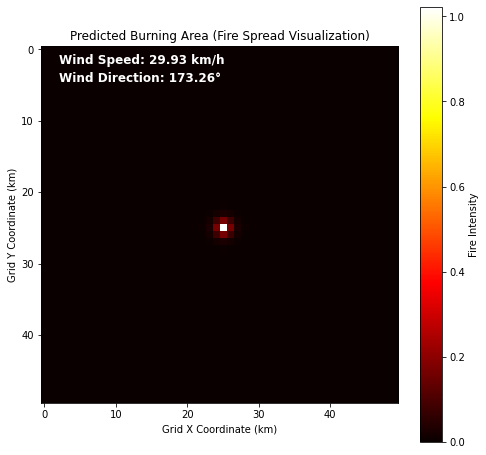

```python
import numpy as np
import pandas as pd
import matplotlib.pyplot as plt
from sklearn.model_selection import train_test_split
from sklearn.ensemble import RandomForestRegressor

# Create a synthetic dataset for the model
np.random.seed(42)
data = {
    'Temperature': np.random.normal(30, 5, 1000),  # Temperature in degrees Celsius
    'Humidity': np.random.normal(40, 10, 1000),  # Relative humidity percentage
    'Wind_Speed': np.random.normal(15, 5, 1000),  # Wind speed in km/h
    'Wind_Direction': np.random.uniform(0, 360, 1000),  # Wind direction in degrees (0-360)
    'Vegetation_Type': np.random.choice(['Forest', 'Grassland', 'Scrubland'], 1000),
    'Initial_Fire_Intensity': np.random.normal(0.5, 0.1, 1000),  # Initial fire intensity
    'Fire_Spread': np.random.normal(5, 2, 1000),  # Fire spread speed (in km/h)
    'Fire_Direction': np.random.uniform(0, 360, 1000),  # Fire spread direction (in degrees)
    'Fire_Area': np.random.normal(100, 30, 1000)  # Fire area in km² (area affected)
}

# Convert the dataset to a DataFrame
df = pd.DataFrame(data)

# Convert categorical variables to numerical (one-hot encoding for Vegetation_Type)
df = pd.get_dummies(df, columns=['Vegetation_Type'], drop_first=True)

# Split the data into features (X) and targets (y)
X = df.drop(['Fire_Spread', 'Fire_Direction', 'Fire_Area'], axis=1)  # Features
y = df[['Fire_Spread', 'Fire_Direction', 'Fire_Area']]  # Targets (speed, direction, area)

# Split into training and testing datasets
X_train, X_test, y_train, y_test = train_test_split(X, y, test_size=0.2, random_state=42)

# Train a RandomForestRegressor model for fire speed, direction, and area prediction
model = RandomForestRegressor(n_estimators=100, random_state=42)

# Fit the model to predict fire speed, direction, and area
model.fit(X_train, y_train)

# Predict fire spread speed, direction, and area on the test set
y_pred = model.predict(X_test)

# Assume we pick a single test sample for visualization
sample = X_test.iloc[0]
predicted_speed = y_pred[0][0]  # Fire spread speed in km/h
predicted_direction = y_pred[0][1]  # Fire spread direction in degrees
predicted_area = y_pred[0][2]  # Fire area in km²
predicted_wind_speed = sample['Wind_Speed']  # Wind speed in km/h
predicted_wind_direction = sample['Wind_Direction']  # Wind direction in degrees

# Print out the predicted values
print(f"Predicted Fire Spread Speed: {predicted_speed:.2f} km/h")
print(f"Predicted Fire Direction: {predicted_direction:.2f} degrees")
print(f"Predicted Fire Area: {predicted_area:.2f} km²")
print(f"Predicted Wind Speed: {predicted_wind_speed:.2f} km/h")
print(f"Predicted Wind Direction: {predicted_wind_direction:.2f} degrees")

# Now let's create a grid to visualize the predicted burning area
# Assuming a 100x100 grid (for example, a 100 km x 100 km area)
grid_size = 50
burning_area_grid = np.zeros((grid_size, grid_size))

# Let's simulate fire spread based on the predicted speed and direction
# We assume that the fire starts in the center of the grid
center_x, center_y = grid_size // 2, grid_size // 2

# Convert direction to radians for calculation
direction_radians = np.deg2rad(predicted_direction)

# Use a simple formula to spread the fire outwards
for x in range(grid_size):
    for y in range(grid_size):
        # Calculate the distance from the center (fire origin)
        distance = np.sqrt((x - center_x)**2 + (y - center_y)**2)

        # The intensity of the fire decreases with distance, but is affected by speed and area
        intensity = np.exp(-distance / (predicted_speed * 0.1)) * (predicted_area / 100)

        # Set the grid cell to the intensity value (scaled by the fire's spread)
        burning_area_grid[x, y] = intensity

# Visualize the predicted burning area
plt.figure(figsize=(8, 8))
plt.imshow(burning_area_grid, cmap='hot', interpolation='nearest')
plt.colorbar(label='Fire Intensity')
plt.title('Predicted Burning Area (Fire Spread Visualization)')
plt.xlabel('Grid X Coordinate (km)')
plt.ylabel('Grid Y Coordinate (km)')

# Add annotations for wind speed and direction on the plot
plt.annotate(f'Wind Speed: {predicted_wind_speed:.2f} km/h',
             xy=(0.05, 0.95), xycoords='axes fraction',
             fontsize=12, color='white', weight='bold')
plt.annotate(f'Wind Direction: {predicted_wind_direction:.2f}°',
             xy=(0.05, 0.90), xycoords='axes fraction',
             fontsize=12, color='white', weight='bold')

# Display the plot
plt.show()
```

```
Predicted Fire Spread Speed: 5.49 km/h
Predicted Fire Direction: SE (134.85°)
Predicted Fire Area: 102.21 km²
Current Wind Speed: 29.93 km/h
Current Wind Direction: S (173.26°)

Test Sample Independent Variables:
Temperature: 32.72
Humidity: 45.82
Wind_Speed: 29.93
Wind_Direction: 173.26
Initial_Fire_Intensity: 0.59
Vegetation_Type_Grassland: 1.00
Vegetation_Type_Scrubland: 0.00
```

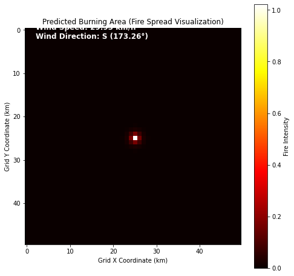

```python
import numpy as np
import pandas as pd
import matplotlib.pyplot as plt
from sklearn.model_selection import train_test_split
from sklearn.ensemble import RandomForestRegressor

# Create a synthetic dataset for the model
np.random.seed(42)
data = {
    'Temperature': np.random.normal(30, 5, 1000),  # Temperature in degrees Celsius
    'Humidity': np.random.normal(40, 10, 1000),  # Relative humidity percentage
    'Wind_Speed': np.random.normal(15, 5, 1000),  # Wind speed in km/h
    'Wind_Direction': np.random.uniform(0, 360, 1000),  # Wind direction in degrees (0-360)
    'Vegetation_Type': np.random.choice(['Forest', 'Grassland', 'Scrubland'], 1000),
    'Initial_Fire_Intensity': np.random.normal(0.5, 0.1, 1000),  # Initial fire intensity
    'Fire_Spread': np.random.normal(5, 2, 1000),  # Fire spread speed (in km/h)
    'Fire_Direction': np.random.uniform(0, 360, 1000),  # Fire spread direction (in degrees)
    'Fire_Area': np.random.normal(100, 30, 1000)  # Fire area in km² (area affected)
}

# Convert the dataset to a DataFrame
df = pd.DataFrame(data)

# Convert categorical variables to numerical (one-hot encoding for Vegetation_Type)
df = pd.get_dummies(df, columns=['Vegetation_Type'], drop_first=True)

# Split the data into features (X) and targets (y)
X = df.drop(['Fire_Spread', 'Fire_Direction', 'Fire_Area'], axis=1)  # Features
y = df[['Fire_Spread', 'Fire_Direction', 'Fire_Area']]  # Targets (speed, direction, area)

# Split into training and testing datasets
X_train, X_test, y_train, y_test = train_test_split(X, y, test_size=0.2, random_state=42)

# Train a RandomForestRegressor model for fire speed, direction, and area prediction
model = RandomForestRegressor(n_estimators=100, random_state=42)

# Fit the model to predict fire speed, direction, and area
model.fit(X_train, y_train)

# Predict fire spread speed, direction, and area on the test set
y_pred = model.predict(X_test)

# Assume we pick a single test sample for visualization
sample = X_test.iloc[0]
predicted_speed = y_pred[0][0]  # Fire spread speed in km/h
predicted_direction = y_pred[0][1]  # Fire spread direction in degrees
predicted_area = y_pred[0][2]  # Fire area in km²
predicted_wind_speed = sample['Wind_Speed']  # Wind speed in km/h
predicted_wind_direction = sample['Wind_Direction']  # Wind direction in degrees

# Function to convert degrees to cardinal direction
def degrees_to_direction(degrees):
    directions = ['N', 'NNE', 'NE', 'ENE', 'E', 'ESE', 'SE', 'SSE', 'S', 'SSW', 'SW', 'WSW', 'W', 'WNW', 'NW', 'NNW']
    index = round(degrees / 22.5) % 16  # Map degree to nearest direction
    return directions[index], degrees

# Convert predicted wind direction and fire direction to string with degrees
wind_direction_str, wind_direction_deg = degrees_to_direction(predicted_wind_direction)
fire_direction_str, fire_direction_deg = degrees_to_direction(predicted_direction)

# Print out the predicted values for fire and current wind information
print(f"Predicted Fire Spread Speed: {predicted_speed:.2f} km/h")
print(f"Predicted Fire Direction: {fire_direction_str} ({fire_direction_deg:.2f}°)")
print(f"Predicted Fire Area: {predicted_area:.2f} km²")
print(f"Current Wind Speed: {predicted_wind_speed:.2f} km/h")
print(f"Current Wind Direction: {wind_direction_str} ({wind_direction_deg:.2f}°)")

# Display all independent variables (features) for the test sample
print("\nTest Sample Independent Variables:")
for feature, value in sample.items():
    print(f"{feature}: {value:.2f}")

# Now let's create a grid to visualize the predicted burning area
# Assuming a 100x100 grid (for example, a 100 km x 100 km area)
grid_size = 50
burning_area_grid = np.zeros((grid_size, grid_size))

# Let's simulate fire spread based on the predicted speed and direction
# We assume that the fire starts in the center of the grid
center_x, center_y = grid_size // 2, grid_size // 2

# Convert fire direction to radians for calculation
direction_radians = np.deg2rad(predicted_direction)

# Use a simple formula to spread the fire outwards
for x in range(grid_size):
    for y in range(grid_size):
        # Calculate the distance from the center (fire origin)
        distance = np.sqrt((x - center_x)**2 + (y - center_y)**2)

        # The intensity of the fire decreases with distance, but is affected by speed and area
        intensity = np.exp(-distance / (predicted_speed * 0.1)) * (predicted_area / 100)

        # Set the grid cell to the intensity value (scaled by the fire's spread)
        burning_area_grid[x, y] = intensity

# Visualize the predicted burning area
plt.figure(figsize=(8, 8))
plt.imshow(burning_area_grid, cmap='hot', interpolation='nearest')
plt.colorbar(label='Fire Intensity')
plt.title('Predicted Burning Area (Fire Spread Visualization)')
plt.xlabel('Grid X Coordinate (km)')
plt.ylabel('Grid Y Coordinate (km)')

# Add annotations for wind speed and direction on the plot
plt.annotate(f'Wind Speed: {predicted_wind_speed:.2f} km/h\nWind Direction: {wind_direction_str} ({wind_direction_deg:.2f}°)',
             xy=(0.05, 0.95), xycoords='axes fraction',
             fontsize=12, color='white', weight='bold')

# Display the plot
plt.show()
```